# cremes-i-incendis

Lucía Martinez Maragreto

```r
library(sf)
library(dplyr)
library(lubridate)
library(ggplot2)
library(purrr)
library(tidyr)
```

Es carreguen les capes d’incendis i de cremes prescrites.

```r
inc <- st_read("dades/processades/incendis_2000_2024.gpkg")
cremes <- st_read("dades/processades/cremes.gpkg")
```

S’extreu l’any de cada crema prescrita a partir de la data disponible per facilitar les comparacions temporals.

```r
cremes <- cremes %>% mutate(ANY = year(ymd(DATA_CREMA)))
```

Es defineix una funció que identifica les cremes prescrites que presenten almenys un incendi posterior dins un radi espacial i un interval temporal determinats.

```r
marca_incendi_post <- function(cremes_sf, inc_sf, radi_m, anys_post) {

  cremes_sf <- cremes_sf %>% mutate(ID_crema = row_number())
  inc_sf <- inc_sf %>% mutate(ID_inc = row_number())

  cremes_buffer <- st_buffer(cremes_sf, dist = radi_m)

  inc_crema_join <- st_join(
    inc_sf %>% select(ID_inc, ANY_inc = ANY, geom),
    cremes_buffer %>% select(ID_crema, ANY_crema = ANY, geom),
    join = st_intersects,
    left = FALSE
  )

  inc_crema_join <- inc_crema_join %>%
    filter(ANY_inc > ANY_crema & (ANY_inc - ANY_crema) <= anys_post)

  cremes_amb_incendi <- unique(inc_crema_join$ID_crema)
  incendi_post <- seq_len(nrow(cremes_sf)) %in% cremes_amb_incendi

  return(incendi_post)
}
```

Es calcula el nombre i el percentatge de cremes prescrites que tenen un incendi posterior per a diferents combinacions de radi i anys posteriors.

```r
radis <- c(500, 1000, 2000)
anys_post <- c(1, 2, 3)

resultats <- expand.grid(radi = radis, anys = anys_post) %>%
  rowwise() %>%
  mutate(
    incendi_post = list(marca_incendi_post(cremes, inc, radi_m = radi, anys_post = anys)),
    n_cremes = sum(unlist(incendi_post)),
    percent_cremes = 100 * n_cremes / nrow(cremes)
  ) %>%
  select(radi, anys, n_cremes, percent_cremes)

print(resultats)
```

```
## # A tibble: 9 × 4
## # Rowwise:
##    radi  anys n_cremes percent_cremes
##   <dbl> <dbl>    <int>          <dbl>
## 1   500     1        5          0.919
## 2  1000     1       11          2.02
## 3  2000     1       22          4.04
## 4   500     2        8          1.47
## 5  1000     2       14          2.57
## 6  2000     2       30          5.51
## 7   500     3        9          1.65
## 8  1000     3       18          3.31
## 9  2000     3       41          7.54
```

Es representen els percentatges de cremes amb incendi posterior en funció del radi espacial i els anys transcorreguts.

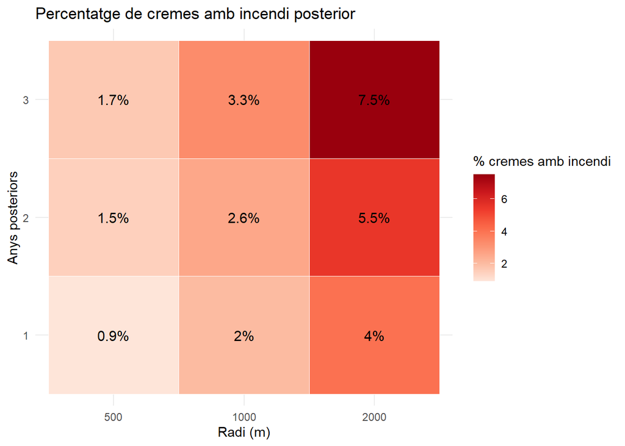

```r
ggplot(resultats, aes(x = factor(radi), y = factor(anys), fill = percent_cremes)) +
  geom_tile(color = "white") +
  geom_text(aes(label = paste0(round(percent_cremes,1), "%")), color = "black", size = 4) +
  scale_fill_distiller(palette = "Reds", direction = 1) +
  labs(
    title = "Percentatge de cremes amb incendi posterior",
    x = "Radi (m)",
    y = "Anys posteriors",
    fill = "% cremes amb incendi"
  ) +
  theme_minimal()
```

Es defineix una funció que determina si un incendi té alguna crema prescrita prèvia dins un radi i un nombre d’anys anteriors.

```r
incidencia_crema_previa <- function(inc_sf, cre_sf, radi_m, anys_anteriors) {

  cre_sf <- st_transform(cre_sf, st_crs(inc_sf))

  if(!"ANY" %in% colnames(cre_sf)) {
    cre_sf <- cre_sf %>% mutate(ANY = year(ymd(DATA_CREMA)))
  }

  inc_buffer <- st_buffer(inc_sf, dist = radi_m)

  inc_buffer <- inc_buffer %>% mutate(ID_inc = row_number())
  cre_sf <- cre_sf %>% mutate(ID_crema = row_number())

  join_sf <- st_join(inc_buffer, cre_sf, join = st_intersects, left = FALSE)

  join_sf <- join_sf %>%
    filter(ANY.y < ANY.x,
           ANY.y >= (ANY.x - anys_anteriors))

  inc_amb_crema <- unique(join_sf$ID_inc)

  inc_sf$has_crema_previa <- inc_sf %>%
    row_number() %in% inc_amb_crema

  inc_sf
}
```

S’aplica la funció de detecció de cremes prèvies als incendis per a totes les combinacions de radi i anys considerats.

```r
radis <- c(500, 1000, 2000)
anys_ant <- c(1, 2, 3)

parametres <- expand.grid(
  radi = radis,
  anys = anys_ant
)

resultats_inc <- parametres %>%
  mutate(
    inc_mod = map2(
      radi, anys,
      ~ incidencia_crema_previa(
        inc_sf = inc,
        cre_sf = cremes,
        radi_m = .x,
        anys_anteriors = .y
      )
    )
  )
```

Es calcula el percentatge d’incendis amb crema prescrita prèvia i les mitjanes d’hectàrees cremades per a cada combinació de paràmetres.

```r
resum_incendis <- resultats_inc %>%
  mutate(
    resum = map(
      inc_mod,
      ~ .x %>%
        st_drop_geometry() %>%
        summarise(
          n_incendis = n(),
          percent_inc_amb_crema = mean(has_crema_previa) * 100,
          mitjana_ha_amb_crema =
            mean(HA_CREMADES[has_crema_previa], na.rm = TRUE),
          mitjana_ha_sense_crema =
            mean(HA_CREMADES[!has_crema_previa], na.rm = TRUE)
        )
    )
  ) %>%
  unnest(resum)

print(resum_incendis)
```

```
## # A tibble: 9 × 7
##    radi  anys inc_mod n_incendis percent_inc_amb_crema mitjana_ha_amb_crema
##   <dbl> <dbl> <list>       <int>                 <dbl>                <dbl>
## 1   500     1 <sf>           503                 0.199                 21.0
## 2  1000     1 <sf>           503                 0.398                 17.8
## 3  2000     1 <sf>           503                 1.19                  38.5
## 4   500     2 <sf>           503                 0.398                 50.0
## 5  1000     2 <sf>           503                 0.596                 38.2
## 6  2000     2 <sf>           503                 1.59                  40.9
## 7   500     3 <sf>           503                 0.596                 37.0
## 8  1000     3 <sf>           503                 1.39                  74.0
## 9  2000     3 <sf>           503                 2.58                 262.
## # ℹ 1 more variable: mitjana_ha_sense_crema <dbl>
```

Es representen els percentatges d’incendis que han tingut una crema prescrita prèvia segons el radi i els anys anteriors.

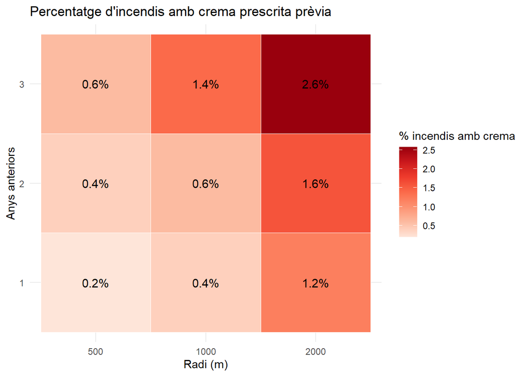

```r
ggplot(resum_incendis,
       aes(x = factor(radi),
           y = factor(anys),
           fill = percent_inc_amb_crema)) +
  geom_tile(color = "white") +
  geom_text(aes(label = paste0(round(percent_inc_amb_crema, 1), "%")),
            size = 4) +
  scale_fill_distiller(palette = "Reds", direction = 1) +
  labs(
    title = "Percentatge d'incendis amb crema prescrita prèvia",
    x = "Radi (m)",
    y = "Anys anteriors",
    fill = "% incendis amb crema"
  ) +
  theme_minimal()
```

Es reestructuren les dades per facilitar la comparació de les hectàrees cremades mitjanes entre incendis amb crema prèvia i sense.

```r
dades_mitjanes <- resum_incendis %>%
  pivot_longer(
    cols = c(mitjana_ha_amb_crema, mitjana_ha_sense_crema),
    names_to = "tipus",
    values_to = "mitjana_ha"
  ) %>%
  mutate(
    tipus = recode(tipus,
                   mitjana_ha_amb_crema = "Amb crema prèvia",
                   mitjana_ha_sense_crema = "Sense crema prèvia")
  )
```

Es representen les mitjanes d’hectàrees cremades en funció de la presència de cremes prèvies, el radi considerat i els anys anteriors.

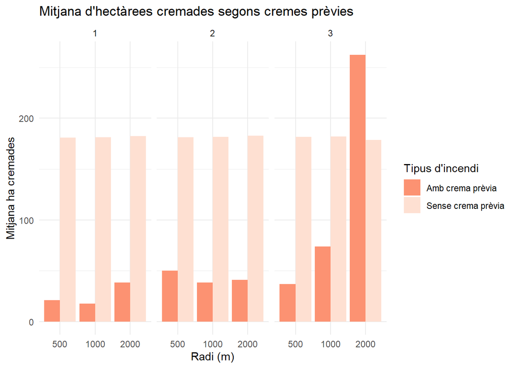

```r
ggplot(dades_mitjanes,
       aes(x = factor(radi),
           y = mitjana_ha,
           fill = tipus)) +
  geom_col(position = "dodge") +
  facet_wrap(~ anys) +
  scale_fill_brewer(palette = "Reds", direction = -1) +
  labs(
    title = "Mitjana d'hectàrees cremades segons cremes prèvies",
    x = "Radi (m)",
    y = "Mitjana ha cremades",
    fill = "Tipus d'incendi"
  ) +
  theme_minimal()
```

```r
cremes <- cremes %>%
  mutate(ID = 1:nrow(.)) %>%
  select(ID, ANY, HECTARES, geom)

radis <- c(500, 1000, 2000)
for (r in radis) {

  cremes_buf <- cremes %>%
    st_buffer(dist = r) %>%
    st_simplify(dTolerance = r / 10) %>%
    st_transform(4326)

  saveRDS(
    cremes_buf,
    paste0("shiny/data/cremes_buffer_", r, ".rds")
  )
}
```

```r
saveRDS(cremes, "shiny/data/cremes.rds")
```